# Relación entre los hábitos de sueño de estudiantes universitarios y su desempeño académico

Hábitos de sueño y el rendimiento académico

# Introducción

## Relevancia

La relación entre la calidad del sueño y el rendimiento cognitivo en humanos es un tema reciente de investigación. Por un lado, decidimos enfocarnos en estudiantes universitarios porque poseen un horario de sueño muy variado y por ende, una baja calidad de sueño. Esto puede afectar a la memoria (Álvarez Navarrete et al., 2020), aumentar el riesgo de desarrollar demencia o Alzheimer (Lira y Custodio, 2018), y modificar el ritmo circadiano (Saavedra Torres et al., 2013). Por otro lado, nuestra investigación está orientada al desempeño académico debido a que este se ve afectado negativamente por el deterioro de la salud por la falta de sueño. Existen diversos estudios sobre la relación entre las horas del sueño y el rendimiento académico en estudiantes de medicina (Pérez-Olmos, 2006); sin embargo, no encontramos muchos estudios enfocados a estudiantes universitarios en general.

## Objetivo general

- Identificar y describir la relación entre los hábitos de sueño y el desempeño académico en estudiantes universitarios.

## Objetivos específicos

- Evaluar el impacto de los hábitos de sueño de los estudiantes en su salud.
- Determinar si los estudiantes duermen lo suficiente de acuerdo a su grupo etario.
- Determinar si existe una relación entre el tiempo de sueño y la carrera universitaria.

## Contexto

Utilizamos como guía una tesis realizada por Rosales-Mayor (2009) para la generación de preguntas de la encuesta. Esto es porque su trabajo trata sobre adaptar una escala de evaluación de somnolencia para la población peruana, lo que nos permite una mejor evaluación de los hábitos de sueño de los estudiantes.

# Análisis descriptivo

## Datos

### Proceso de recolección

1. Elección de la herramienta: Se decidió utilizar Google Forms debido a su facilidad de uso, flexibilidad y capacidad para recopilar respuestas de forma organizada y segura.
2. Diseño del cuestionario: Se diseñó un cuestionario que incluía preguntas relevantes para el estudio sobre las horas de sueño promedio, rendimiento académico, fatiga y factores relacionados.
3. Definición de las condiciones: El cuestionario asegura la confidencialidad de los datos y solicita verificación de usuario.
4. Estrategias de alcance: La difusión del cuestionario es mediante canales de comunicación internos, como telegram, grupos estudiantiles y redes sociales. Además, se invitó a los estudiantes a responder la encuesta mediante el uso del código QR.
5. Validación y control de calidad: Se revisa si existen respuestas inconsistentes o atípicas, así como la verificación de que no se hayan introducido datos erróneos.

### Cuestionario

[Enlace del cuestionario](https://forms.gle/MToHD7xQz8nwP3Cr9)

### Población, muestra y muestreo

En este estudio, la población fueron los estudiantes universitarios de UTEC. Se obtuvo una muestra de 138 observaciones, seleccionada mediante un muestreo aleatorio simple, con el objetivo de obtener una muestra representativa de los estudiantes de la UTEC y poder generalizar los resultados obtenidos a toda la población estudiantil.

## Variables

| VARIABLE | TIPO | RESTRICCIONES |  |
| --- | --- | --- | --- |
| Edad | Numérica discreta | *Debe ser un entero positivo* |  |
| Ciclo | Categórica Ordinal | *No puede ser negativo ni mayor a 10* |  |
| Carrera | Categórica nominal | *Debe ser una carrera disponible en UTEC* |  |
| Tiempo de sueño | Categórica ordinal | *Solo puede ser menos de 3, de 3 - 5, de 6 - 8 o más de 8 horas* |  |
| Calidad de sueño | Numérica discreta | *No puede ser un número mayor a 5 o menor a 1* |  |
| Dificultad al dormir | Numérica discreta | *No puede ser un número mayor a 5 ni menor a 1* |  |
| Desempeño académico | Numérica discreta | *No puede ser un número mayor a 5 ni menor a 1* |  |
| Fatiga | Numérica discreta | *No puede ser un número mayor a 5 ni menor a 1* |  |
| Bebidas energizantes | Categórica ordinal | *Solo puede ser 0, 1, 2, 3 o más de 3* |  |
| Actividad física | Categórica ordinal | *Solo puede ser no realizo ejercicio, 1-2 veces a la semana, 3-4 veces a la semana, 5-6 veces a la semana o me ejercito todos los días* |  |
| Nivel de estrés | Numérica discreta | *No puede ser un número mayor a 5 ni menor a 1* |  |
| Aparatos electrónicos | Numérica discreta | *No puede ser un número mayor a 5 ni menor a 1* |  |
| Horas de estudio | Numérica discreta | *No puede ser un número mayor a 5 ni menor a 1* |  |
| Noches sin dormir | Categórica nominal | *Solo puede ser sí o no* |  |
| Abrumado | Numérica Discreta | *No puede ser un número mayor a 5 ni menor a 1* |  |
| Siestas | Numérica Discreta | *No puede ser un número mayor a 5 ni menor a 1* |  |
| Bebidas alcohólicas | Numérica Discreta | *No puede ser un número mayor a 5 ni menor a 1* |  |
| Opinión del tema | Categórica nominal | *Solo puede ser sí o no* |  |
| Insomnio | Numérica Discreta | *No puede ser un entero negativo* |  |
| Act. extracurriculares | Categórica ordinal | *Solo puede ser 1 a 2 horas, 2 a 4 horas, 4 a 6 horas, más de 6 horas o no tengo otros compromisos* |  |
| Eventos académicos | Numérica Discreta | *No puede ser un número mayor a 5 ni menor a 1* |  |
| Salud mental | Categórica nominal | *Solo puede ser sí o no* |  |
| Consulta psicológica | Categórica nominal | *Solo puede ser sí o no* |  |

## Limpieza de base de datos

La encuesta presentaba preguntas de opciones múltiples, esto evita que las observaciones presenten algún dato anormal. Gracias a esto, al revisar los datos, no encontramos respuestas mal escritas, o números fuera de un rango habitual. El único problema de esta decisión es que se terminan limitando las respuestas y eliminando la “variedad” de las mismas, ya que hay opciones predeterminadas. Esto se toma como recomendación para futuras investigaciones.

Los cambios realizados están enfocados en la definición de las variables y cómo planteamos sus posibles valores.

```r
install.packages("readr",repos='http://cran.us.r-project.org')
install.packages("dplyr", repos='http://cran.us.r-project.org')
```

```r
install.packages("ggplot2", repos='http://cran.us.r-project.org')
```

```
##
##   There is a binary version available but the source version is later:
##         binary source needs_compilation
## ggplot2  3.4.2  3.4.3             FALSE
```

```
## installing the source package 'ggplot2'
```

```r
library(readr)
library(dplyr)
```

```r
library(ggplot2)
DP <- read_csv("Encuesta.csv")
```

Proceso utilizado para saber si existen datos atípicos u observaciones incompletas:

1. Verificamos si los descriptores tienen lógica:

```r
summary(DP)
```

```
##  Marca temporal          Edad           Ciclo          Carrera
##  Length:138         Min.   :17.00   Min.   : 1.000   Length:138
##  Class :character   1st Qu.:18.00   1st Qu.: 3.000   Class :character
##  Mode  :character   Median :19.00   Median : 4.000   Mode  :character
##                     Mean   :19.33   Mean   : 3.797
##                     3rd Qu.:20.00   3rd Qu.: 4.000
##                     Max.   :25.00   Max.   :10.000
##    TiempoS             CalidadS      DificultadD      DesempeñoA
##  Length:138         Min.   :1.000   Min.   :1.000   Min.   :2.000
##  Class :character   1st Qu.:3.000   1st Qu.:2.000   1st Qu.:3.000
##  Mode  :character   Median :3.000   Median :3.000   Median :3.000
##                     Mean   :3.123   Mean   :2.688   Mean   :3.493
##                     3rd Qu.:4.000   3rd Qu.:3.000   3rd Qu.:4.000
##                     Max.   :5.000   Max.   :5.000   Max.   :5.000
##      Fatiga       Bcafeina          Ejercicio            NEstres
##  Min.   :1.00   Length:138         Length:138         Min.   :1.000
##  1st Qu.:3.00   Class :character   Class :character   1st Qu.:3.000
##  Median :3.00   Mode  :character   Mode  :character   Median :4.000
##  Mean   :3.29                                         Mean   :3.442
##  3rd Qu.:4.00                                         3rd Qu.:4.000
##  Max.   :5.00                                         Max.   :5.000
##   DispositivoE     HEstudio            NocheE            AbrumadoTA
##  Min.   :1.000   Length:138         Length:138         Min.   :1.0
##  1st Qu.:3.250   Class :character   Class :character   1st Qu.:3.0
##  Median :4.000   Mode  :character   Mode  :character   Median :3.5
##  Mean   :4.116                                         Mean   :3.5
##  3rd Qu.:5.000                                         3rd Qu.:4.0
##  Max.   :5.000                                         Max.   :5.0
##     Siestas         AlcoholD      OpinionRA            Insomnio
##  Min.   :1.000   Min.   :1.000   Length:138         Min.   :1.000
##  1st Qu.:1.000   1st Qu.:1.000   Class :character   1st Qu.:1.000
##  Median :2.000   Median :1.000   Mode  :character   Median :2.000
##  Mean   :1.986   Mean   :1.645                      Mean   :2.196
##  3rd Qu.:3.000   3rd Qu.:2.000                      3rd Qu.:3.000
##  Max.   :5.000   Max.   :5.000                      Max.   :5.000
##  CompromisosE          EventosA     SaludMental          Consejo
##  Length:138         Min.   :1.000   Length:138         Length:138
##  Class :character   1st Qu.:2.000   Class :character   Class :character
##  Mode  :character   Median :3.000   Mode  :character   Mode  :character
##                     Mean   :2.659
##                     3rd Qu.:3.750
##                     Max.   :5.000
```

2. Verificamos si hay observaciones incompletas:

```r
table(is.na(DP))
```

```
##
## FALSE
##  3312
```

Por otro lado, tuvimos que recategorizar algunas variables en R y eliminamos la variable “Marca Temporal”. Para esto seguimos los siguientes pasos:

1. Saber el tipo de variables que se tienen:

```r
str(DP)
```

```
## spc_tbl_ [138 x 24] (S3: spec_tbl_df/tbl_df/tbl/data.frame)
##  $ Marca temporal: chr [1:138] "27/04/2023 15:39:05" "27/04/2023 15:39:06" "27/04/2023 15:43:59" "27/04/2023 15:59:32" ...
##  $ Edad          : num [1:138] 18 18 17 17 18 20 19 25 17 22 ...
##  $ Ciclo         : num [1:138] 3 3 3 3 3 4 5 5 1 5 ...
##  $ Carrera       : chr [1:138] "Ciencia de la Computación" "Ingeniería Química" "Ingeniería Química" "Ingeniería Química" ...
##  $ TiempoS       : chr [1:138] "6 a 8 horas" "6 a 8 horas" "3 a 5 horas" "Menos de 3 horas" ...
##  $ CalidadS      : num [1:138] 4 3 2 2 3 2 2 2 3 3 ...
##  $ DificultadD   : num [1:138] 2 4 3 3 3 3 4 4 3 2 ...
##  $ DesempeñoA    : num [1:138] 4 4 4 4 3 3 3 3 4 3 ...
##  $ Fatiga        : num [1:138] 3 4 4 4 4 2 4 4 4 2 ...
##  $ Bcafeina      : chr [1:138] "No consumo" "No consumo" "1" "No consumo" ...
##  $ Ejercicio     : chr [1:138] "1 o 2 veces a la semana" "1 o 2 veces a la semana" "1 o 2 veces a la semana" "1 o 2 veces a la semana" ...
##  $ NEstres       : num [1:138] 2 4 4 3 3 3 4 4 3 1 ...
##  $ DispositivoE  : num [1:138] 5 4 5 4 5 4 3 5 5 5 ...
##  $ HEstudio      : chr [1:138] "2 horas" "3 horas" "3 horas" "3 horas" ...
##  $ NocheE        : chr [1:138] "Sí" "Sí" "Sí" "Sí" ...
##  $ AbrumadoTA    : num [1:138] 4 4 4 3 3 3 4 4 4 2 ...
##  $ Siestas       : num [1:138] 2 1 3 2 2 1 2 2 4 1 ...
##  $ AlcoholD      : num [1:138] 1 1 1 1 2 1 1 2 2 2 ...
##  $ OpinionRA     : chr [1:138] "Sí" "Sí" "Sí" "Sí" ...
##  $ Insomnio      : num [1:138] 1 4 2 2 2 3 1 4 2 3 ...
##  $ CompromisosE  : chr [1:138] "No tengo otros compromisos" "No tengo otros compromisos" "2 a 4 horas" "1 a 2 horas" ...
##  $ EventosA      : num [1:138] 2 5 2 2 2 2 2 4 2 3 ...
##  $ SaludMental   : chr [1:138] "No" "Sí" "Sí" "Sí" ...
##  $ Consejo       : chr [1:138] "No" "No" "Sí" "No" ...
##  - attr(*, "spec")=
##   .. cols(
##   ..   `Marca temporal` = col_character(),
##   ..   Edad = col_double(),
##   ..   Ciclo = col_double(),
##   ..   Carrera = col_character(),
##   ..   TiempoS = col_character(),
##   ..   CalidadS = col_double(),
##   ..   DificultadD = col_double(),
##   ..   DesempeñoA = col_double(),
##   ..   Fatiga = col_double(),
##   ..   Bcafeina = col_character(),
##   ..   Ejercicio = col_character(),
##   ..   NEstres = col_double(),
##   ..   DispositivoE = col_double(),
##   ..   HEstudio = col_character(),
##   ..   NocheE = col_character(),
##   ..   AbrumadoTA = col_double(),
##   ..   Siestas = col_double(),
##   ..   AlcoholD = col_double(),
##   ..   OpinionRA = col_character(),
##   ..   Insomnio = col_double(),
##   ..   CompromisosE = col_character(),
##   ..   EventosA = col_double(),
##   ..   SaludMental = col_character(),
##   ..   Consejo = col_character()
##   .. )
##  - attr(*, "problems")=<externalptr>
```

2. Recategorización de variables y cambios adicionales:

```r
DP$Bcafeina[DP$Bcafeina == "No consumo"] <- "0"
table(DP$Bcafeina)
```

```
##
##        0        1        2        3 Más de 3
##       69       31       24       10        4
```

```r
DP$HEstudio[DP$HEstudio == "1 hora"] <- "1"
DP$HEstudio[DP$HEstudio == "2 horas"] <- "2"
DP$HEstudio[DP$HEstudio == "3 horas"] <- "3"
DP$HEstudio[DP$HEstudio == "4 horas"] <- "4"
table(DP$HEstudio)
```

```
##
##              1              2              3              4 Más de 4 horas
##              9             25             38             30             36
```

```r
DP$Edad<- as.integer(DP$Edad)
DP$Ciclo<- as.integer(DP$Ciclo)
```

3. Eliminación de la variable “Marca Temporal”:

```r
DP$`Marca temporal` <- NULL
```

4. Clasificar a los estudiantes por grupo etario:

```r
DP$GEtario <- ifelse(DP$Edad > 18, "Adulto joven", "Adolescente")
```

5. Clasificar a los estudiantes por facultad (grupos de la semana universitaria):

```r
DP <- DP %>%
  mutate(Facultad = case_when(
    Carrera %in% c('Ingeniería Mecatrónica', 'Ingeniería Electrónica') ~ 'ELMT',
    Carrera %in% c('Bioingeniería', 'Ingeniería Ambiental', 'Ingeniería Química') ~ 'Biochamp',
    Carrera %in% c('Ingeniería Civil', 'Ciencia de Datos', 'Ciencia de la Computación') ~ 'Concreto',
    Carrera %in% c('Administración y Negocios Digitales', 'Ingeniería Industrial') ~ 'WallStreet',
    Carrera %in% c('Ingeniería de la Energía', 'Ingeniería Mecánica') ~ 'MecaWatts'
  ))
```

## Descriptores

### Desempeño académico - Tiempo de Sueño

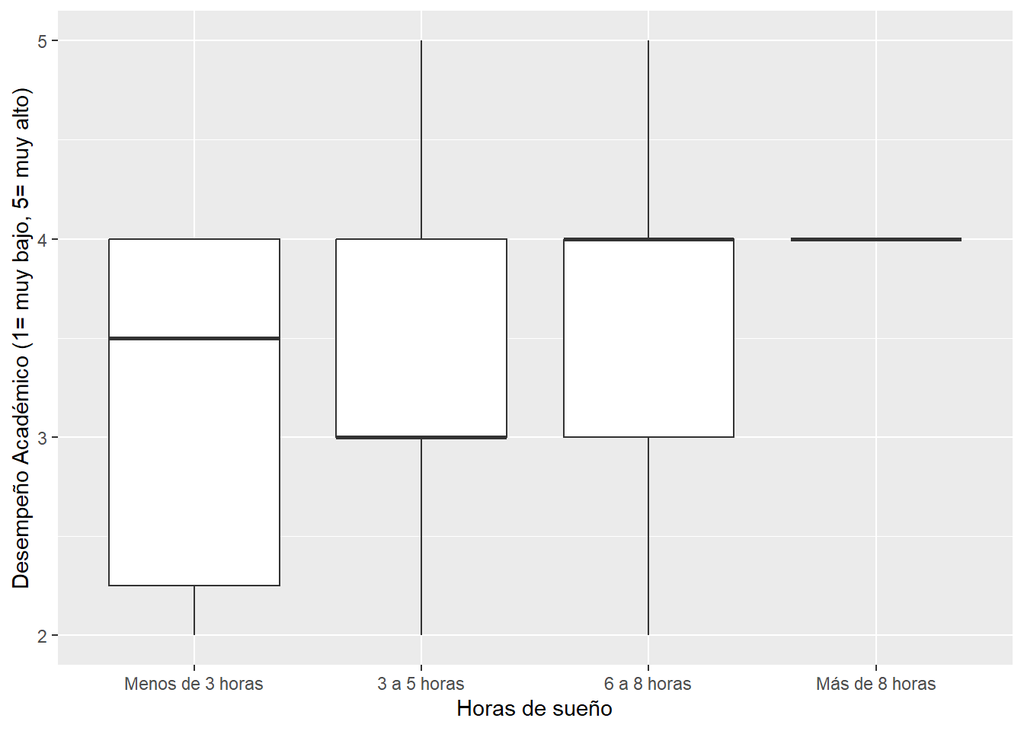

```r
o <- c("Menos de 3 horas","3 a 5 horas","6 a 8 horas","Más de 8 horas")
ggplot(DP, aes(x = TiempoS, y = DesempeñoA)) +
  geom_boxplot() +
  scale_x_discrete(limits = o) +
  labs(x = "Horas de sueño", y = "Desempeño Académico (1= muy bajo, 5= muy alto)")
```

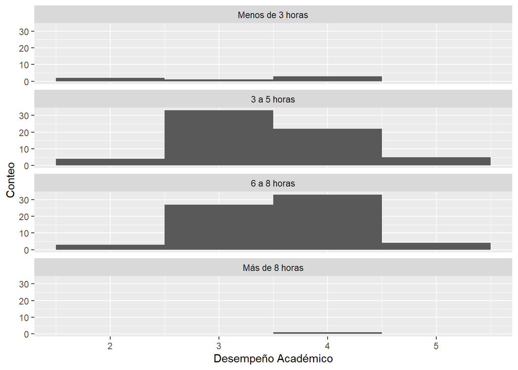

```r
DP$type <- reorder(DP$TiempoS, DP$DesempeñoA)
ggplot(DP, aes(x = DesempeñoA))  +
  geom_histogram(binwidth = 1) +
  xlab("Desempeño Académico") +
  ylab("Conteo") +
  facet_wrap(~ type, ncol = 1)
```

Utilidad: El histograma nos es útil puesto que complementa la información presentada en el gráfico anterior. Observamos que mientras más duermen los estudiantes mayor es su desempeño académico, esto lo notamos comparando las observaciones correspondientes a estudiantes que duermen de 3 a 5 horas y de 6 a 8 horas.

### Grupo Etario - Tiempo de sueño

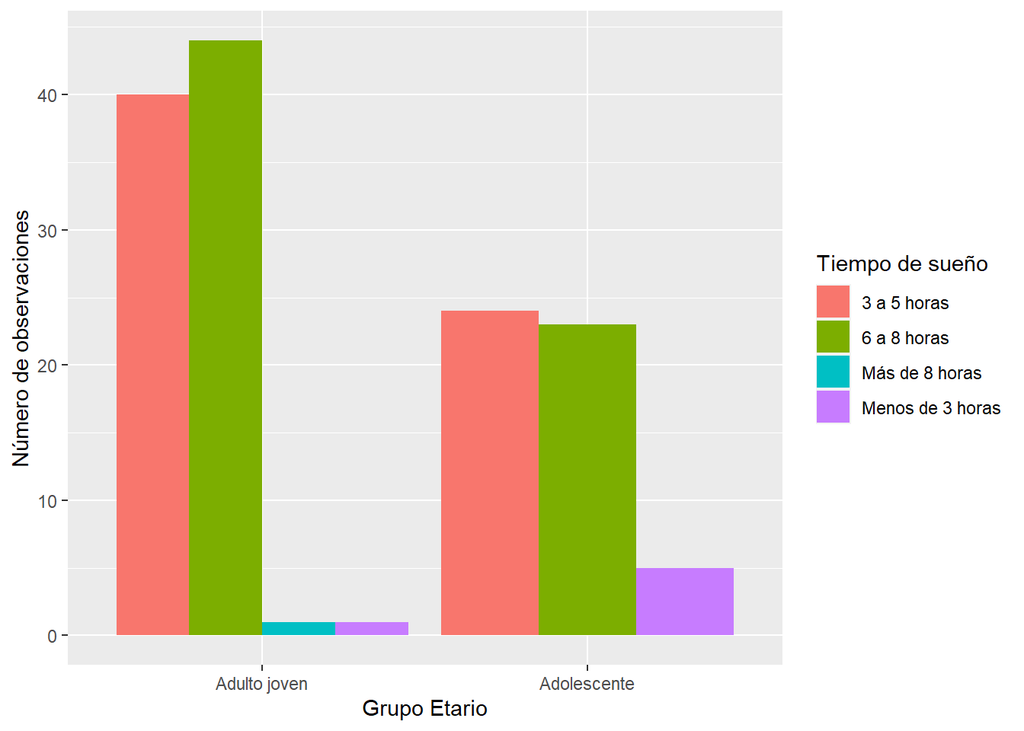

```r
ca <- c("Adulto joven", "Adolescente")
ggplot(DP, aes(x = GEtario, fill = TiempoS)) +
  geom_bar(position = "dodge") +
  scale_x_discrete(limits = ca) +
  labs(x = "Grupo Etario", y = "Número de observaciones", fill = "Tiempo de sueño")
```

Utilidad: Notamos que, a pesar de la diferencia de edad entre ambos grupos, el comportamiento es muy similar. Gran parte de ambos grupos etarios toman entre 3 a 5 horas o entre 6 a 8 horas en dormir. Si tomamos en cuenta las investigaciones de The Sleep Foundation (2023), quienes nos indican que los adolescentes (de 13 a 18 años) deben dormir de 8 a 10 horas y los adultos (de 18 a más) deben dormir de 6 a 8 horas para tener un rendimiento óptimo durante el día, podemos concluir que los adolescentes no están durmiendo las suficientes horas al día. En el caso de los adultos jóvenes, podemos concluir que si bien hay muchos adultos que cumplen con el tiempo necesario de sueño, para tener un buen rendimiento durante el día, estos forman parte de un poco más del 50% de las muestras, mientras que el resto solo duermen de 3 a 5 horas (incluso menos, pero en una cantidad mínima).

### Nivel de estrés

```r
a <- mean(DP$NEstres)
b <- median(DP$NEstres)
c <- IQR(DP$NEstres)
cat("La media es",a,", la medianana es",b,"y tiene un rango intercuantil igual a",c)
```

```
## La media es 3.442029 , la medianana es 4 y tiene un rango intercuantil igual a 1
```

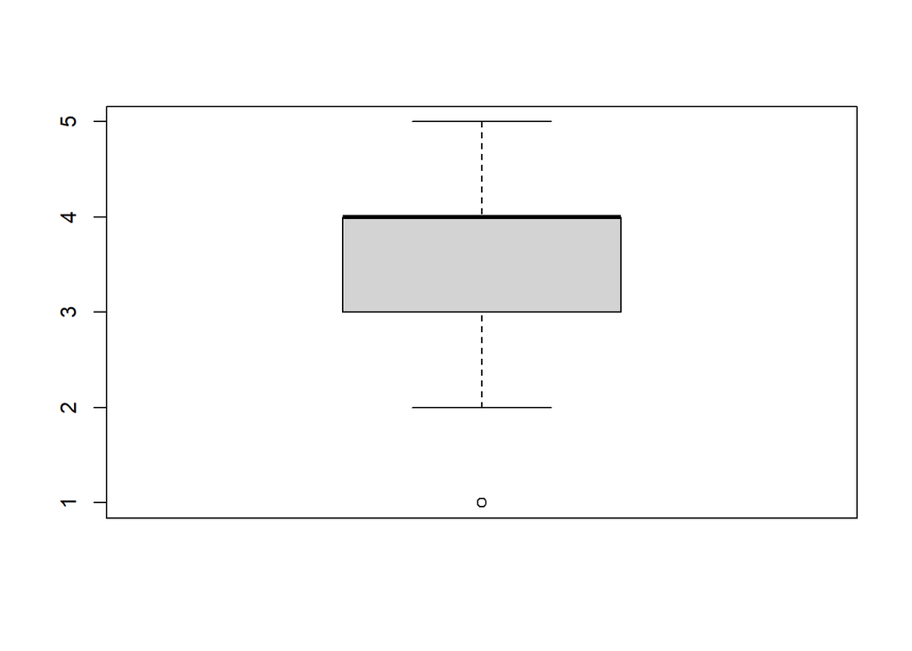

```r
boxplot(DP$NEstres)
```

Utilidad: Calculamos la media, mediana y rango intercuartil para interpretar mejor el diagrama de cajas. El gráfico nos permite observar que la mayoría de los encuestados presentan un nivel de estrés regular o alto (3 o 4, respectivamente). Además notamos que existen pocos estudiantes con un nivel de estrés muy bajo (1).

### Abrumado

```r
table(DP$AbrumadoTA)
```

```
##
##  1  2  3  4  5
##  4 13 52 48 21
```

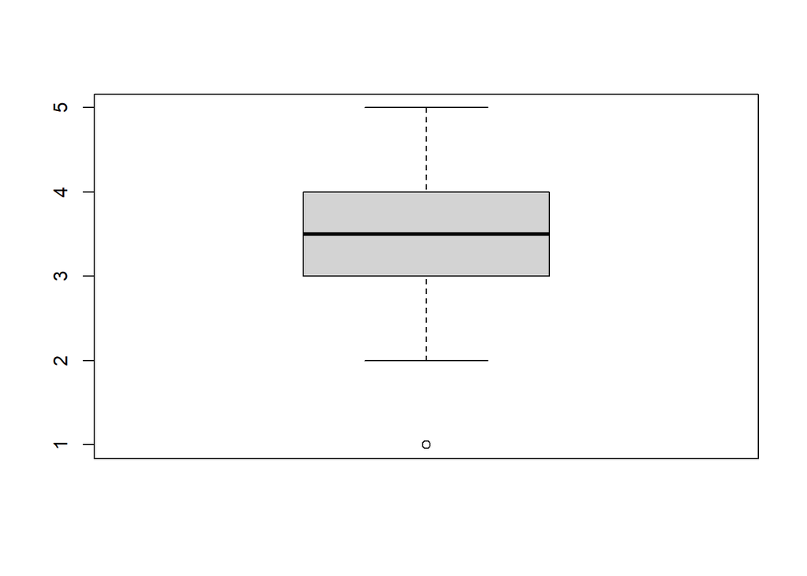

```r
boxplot(DP$AbrumadoTA)
```

Utilidad: Lo primero nos permite observar que la mayoría de los estudiantes se sienten abrumados por la carga académica y lo segundo nos permite una mejor visualización de los datos. Aparte notamos la mediana y rango intercuantil en la gráfica. Observamos que la mayoría de los estudiantes se sienten abrumados por la carga académica a veces o casi siempre. Mientras que, existen muy pocos que nunca se sienten abrumados por esta. Esto nos permite evaluar los niveles de estrés.

### Nivel de fatiga- Dificultad al dormir

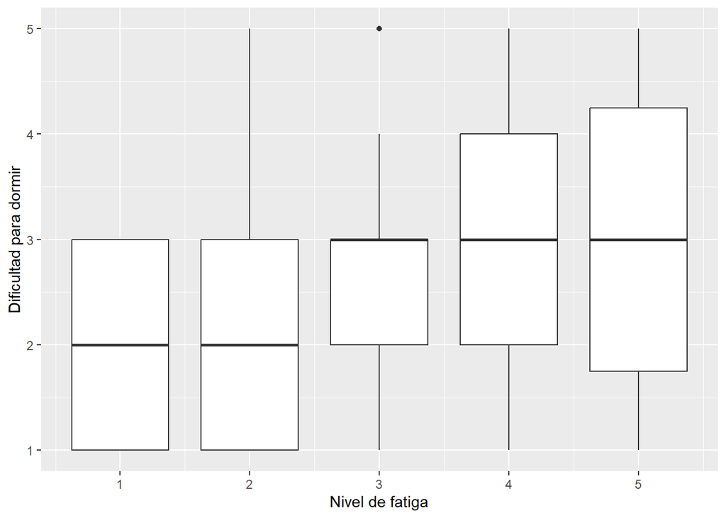

```r
ggplot(data = DP, aes(x = Fatiga, y = DificultadD)) +
  geom_boxplot(mapping = aes(group = cut_width(Fatiga, 1))) +
        labs(x = "Nivel de fatiga", y = "Dificultad para dormir", fill = "n")
```

Utilidad: Nos permite observar si existe una correlación entre ambas variables Dificultad para dormir y nivel de fatiga. Esto es importante en nuestro estudio para determinar los factores que ocasionan una baja calidad de sueño y sus consecuencias en la salud (física y mental). Notamos que existe un nivel de correlación intermedio, podremos confirmar o negar esto en la parte de análisis probabilístico al definir eventos a partir de las variables.

### Calidad de sueño - Carrera

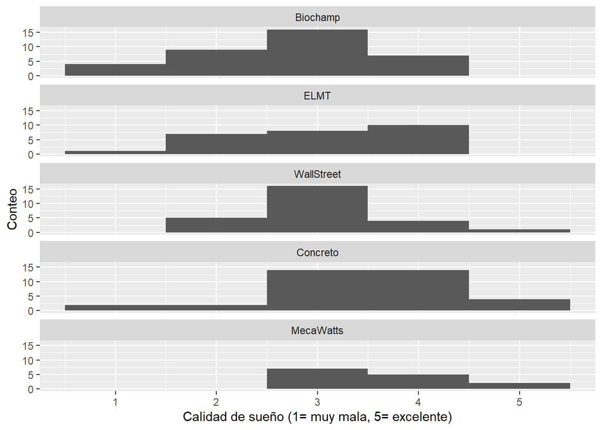

```r
DP$type2 <- reorder(DP$Facultad, DP$CalidadS)
ggplot(DP, aes(x = CalidadS))  +
  geom_histogram(binwidth = 1) +
  xlab("Calidad de sueño (1= muy mala, 5= excelente)") +
  ylab("Conteo") +
  facet_wrap(~ type2, ncol = 1)
```

Utilidad: Permite identificar si la calidad del sueño varía de acuerdo a la facultad (separados según los grupos de la semana universitaria) en la que se encuentran los estudiantes. Podemos notar que los estudiantes de Concreto y MecaWatts poseen una calidad de sueño regular, buena o excelente en su mayoría. En los otros grupos observamos que las calidad de sueño es más variada.

### Siestas

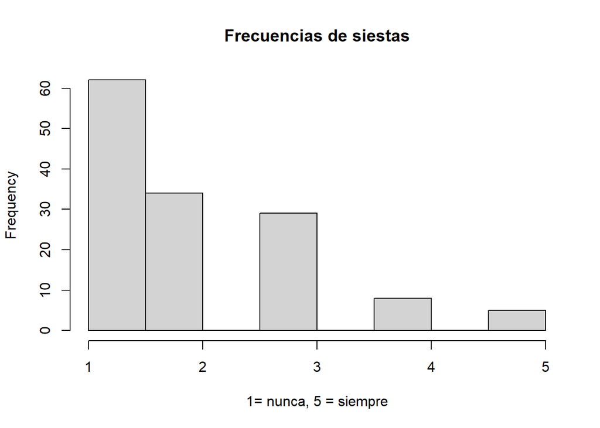

```r
hist(DP$Siestas, main= "Frecuencias de siestas", xlab="1= nunca, 5 = siempre")
```

Utilidad: Nos sirve para identificar la frecuencia con la que los estudiantes universitarios toman siestas. Observamos que existe un sesgo hacia la derecha, esto nos indica que la mayoría de los estudiantes toman siestas con poca frecuencia.

### Actividad física - Grupo Etario

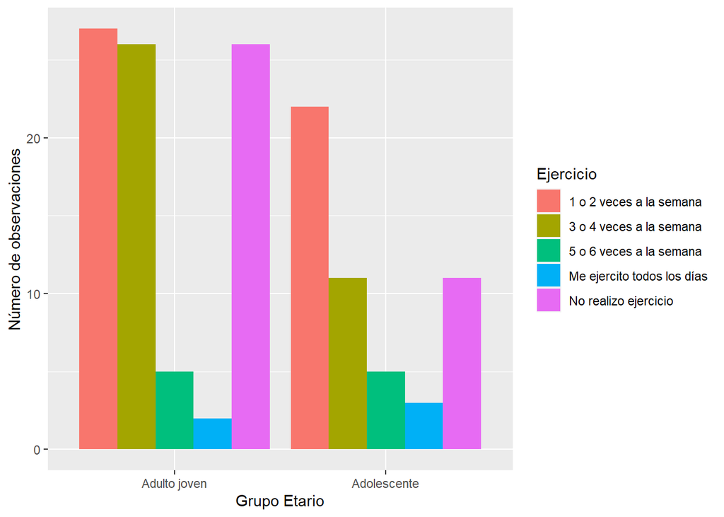

```r
ggplot(DP, aes(x = GEtario, fill = Ejercicio)) +
  geom_bar(position = "dodge") +
  scale_x_discrete(limits = ca) +
  labs(x = "Grupo Etario", y = "Número de observaciones", fill = "Ejercicio")
```

Utilidad: El gráfico nos muestra la relación entre la frecuencia de realización de ejercicios físicos y los grupos etarios. Esta información es útil porque nos permite analizar cómo se distribuye la práctica de ejercicio en diferentes grupos de edad. Observamos que ambos grupos etarios se ejercitan en su mayoría por lo menos una o dos veces a la semana. Sin embargo, los adultos jóvenes poseen una cantidad de personas que no realizan ejercicio casi igual a la de las que lo realizan una o dos veces a la semana. Además, notamos que los adolescentes presentan una menor cantidad de personas que no realizan ejercicio.

# Análisis probabilístico

## Probabilidad empírica

### Espacio Muestral

Para la variable DesempeñoA:

```r
table(DP$DesempeñoA)
```

```
##
##  2  3  4  5
##  9 61 59  9
```

Para la variable TiempoS:

```r
table(DP$TiempoS)
```

```
##
##      3 a 5 horas      6 a 8 horas   Más de 8 horas Menos de 3 horas
##               64               67                1                6
```

### Eventos y funciones de probabilidad

Relacionados a la variable DesempeñoA:

- Evento 1: Escoger una persona con desempeño académico muy alto (5) de una muestra de 138 personas.

```r
9/138
```

```
## [1] 0.06521739
```

- Evento 2: Escoger una persona con desempeño académico alto (4) de una muestra de 138 personas.

```r
59/138
```

```
## [1] 0.4275362
```

- Evento 3: Escoger una persona con desempeño académico regular (3) de una muestra de 138 personas.

```r
61/138
```

```
## [1] 0.442029
```

- Evento 4: Escoger una persona con desempeño académico bajo (2) de una muestra de 138 personas.

```r
9/138
```

```
## [1] 0.06521739
```

- Evento 5: Escoger una persona con desempeño académico muy bajo (1) de una muestra de 138 personas.

```r
0/138
```

```
## [1] 0
```

```r
fi=table(DP$DesempeñoA)
pi=round(prop.table(fi),4)
cbind(fi,pi)
```

```
##   fi     pi
## 2  9 0.0652
## 3 61 0.4420
## 4 59 0.4275
## 5  9 0.0652
```

Relacionados con la variable TiempoS:

- Evento 1: Escoger una persona con un tiempo de sueño de más de 8 horas de una muestra de 138 personas.

```r
1/138
```

```
## [1] 0.007246377
```

- Evento 2: Escoger una persona con un tiempo de sueño de más de 6 a 8 horas de una muestra de 138 personas.

```r
67/138
```

```
## [1] 0.4855072
```

- Evento 3: Escoger una persona con un tiempo de sueño de 3 a 5 horas de una muestra de 138 personas.

```r
64/138
```

```
## [1] 0.4637681
```

- Evento 4: Escoger una persona con un tiempo de sueño de menos de 3 horas de una muestra de 138 personas.

```r
6/138
```

```
## [1] 0.04347826
```